# EDA zestawu danych Gapminder

Paulina Papież

15.01.2026

# Wstęp

Zajmiemy się analizą zestawu danych gapminder, który zawiera informacje społeczno-ekonomiczne i demograficzne dotyczące krajów świata w latach 1952–2007.

# Wgląd na trzy pierwsze wiersze zestawu danych

```r
head(gapminder, 3)
```

```
## # A tibble: 3 × 6
##   country     continent  year lifeExp      pop gdpPercap
##   <fct>       <fct>     <int>   <dbl>    <int>     <dbl>
## 1 Afghanistan Asia       1952    28.8  8425333      779.
## 2 Afghanistan Asia       1957    30.3  9240934      821.
## 3 Afghanistan Asia       1962    32.0 10267083      853.
```

# Wgląd na trzy ostatnie wiersze zestawu danych

```r
tail(gapminder, 3)
```

```
## # A tibble: 3 × 6
##   country  continent  year lifeExp      pop gdpPercap
##   <fct>    <fct>     <int>   <dbl>    <int>     <dbl>
## 1 Zimbabwe Africa     1997    46.8 11404948      792.
## 2 Zimbabwe Africa     2002    40.0 11926563      672.
## 3 Zimbabwe Africa     2007    43.5 12311143      470.
```

# Struktura danych

```r
str(gapminder)
```

```
## tibble [1,704 × 6] (S3: tbl_df/tbl/data.frame)
##  $ country  : Factor w/ 142 levels "Afghanistan",..: 1 1 1 1 1 1 1 1 1 1 ...
##  $ continent: Factor w/ 5 levels "Africa","Americas",..: 3 3 3 3 3 3 3 3 3 3 ...
##  $ year     : int [1:1704] 1952 1957 1962 1967 1972 1977 1982 1987 1992 1997 ...
##  $ lifeExp  : num [1:1704] 28.8 30.3 32 34 36.1 ...
##  $ pop      : int [1:1704] 8425333 9240934 10267083 11537966 13079460 14880372 12881816 13867957 16317921 22227415 ...
##  $ gdpPercap: num [1:1704] 779 821 853 836 740 ...
```

# Podsumowanie danych

```r
summary(gapminder)
```

```
##         country        continent        year         lifeExp
##  Afghanistan:  12   Africa  :624   Min.   :1952   Min.   :23.60
##  Albania    :  12   Americas:300   1st Qu.:1966   1st Qu.:48.20
##  Algeria    :  12   Asia    :396   Median :1980   Median :60.71
##  Angola     :  12   Europe  :360   Mean   :1980   Mean   :59.47
##  Argentina  :  12   Oceania : 24   3rd Qu.:1993   3rd Qu.:70.85
##  Australia  :  12                  Max.   :2007   Max.   :82.60
##  (Other)    :1632
##       pop              gdpPercap
##  Min.   :6.001e+04   Min.   :   241.2
##  1st Qu.:2.794e+06   1st Qu.:  1202.1
##  Median :7.024e+06   Median :  3531.8
##  Mean   :2.960e+07   Mean   :  7215.3
##  3rd Qu.:1.959e+07   3rd Qu.:  9325.5
##  Max.   :1.319e+09   Max.   :113523.1
##
```

```
##  /\     /\
## {  `---'  }
## {  O   O  }
## ==>  V <==  No need for mice. This data set is completely observed.
##  \  \|/  /
##   `-----'
```

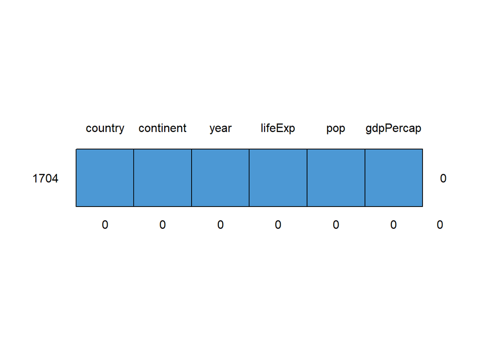

```
##      country continent year lifeExp pop gdpPercap
## 1704       1         1    1       1   1         1 0
##            0         0    0       0   0         0 0
```

```r
md.pattern(gapminder)
```

Nie ma braków danych w zestawie.

## Pytania badawcze

1. Jak zmieniała się oczekiwana długość życia w wybranych krajach (Japonia, Indie, Stany Zjednoczone) w czasie?
2. Które kontynenty mają najwyższą i najniższą średnią PKB per capita?
3. Jaki jest związek między PKB per capita a oczekiwaną długością życia?
4. Jak zmieniała się liczba ludności kontynentów w czasie?
5. Które kraje w 2007 roku miały najwyższe PKB per capita?
6. Jak zmieniła się zależność między PKB per capita a oczekiwaną długością życia w latach 1952 i 2007?
7. Które kraje odnotowały największy wzrost oczekiwanej długości życia w latach 1952–2007?
8. Które kraje miały najniższe PKB per capita w 2007 roku ?
9. Jak kształtowała się średnia oczekiwana długość życia według kontynentów w 2007 roku ?

10.Jak zmieniały się podstawowe wskaźniki społeczno-ekonomiczne w Kamerunie w latach 1952–2007?

# 1. Oczekiwana długość życia w czasie dla wybranych krajów

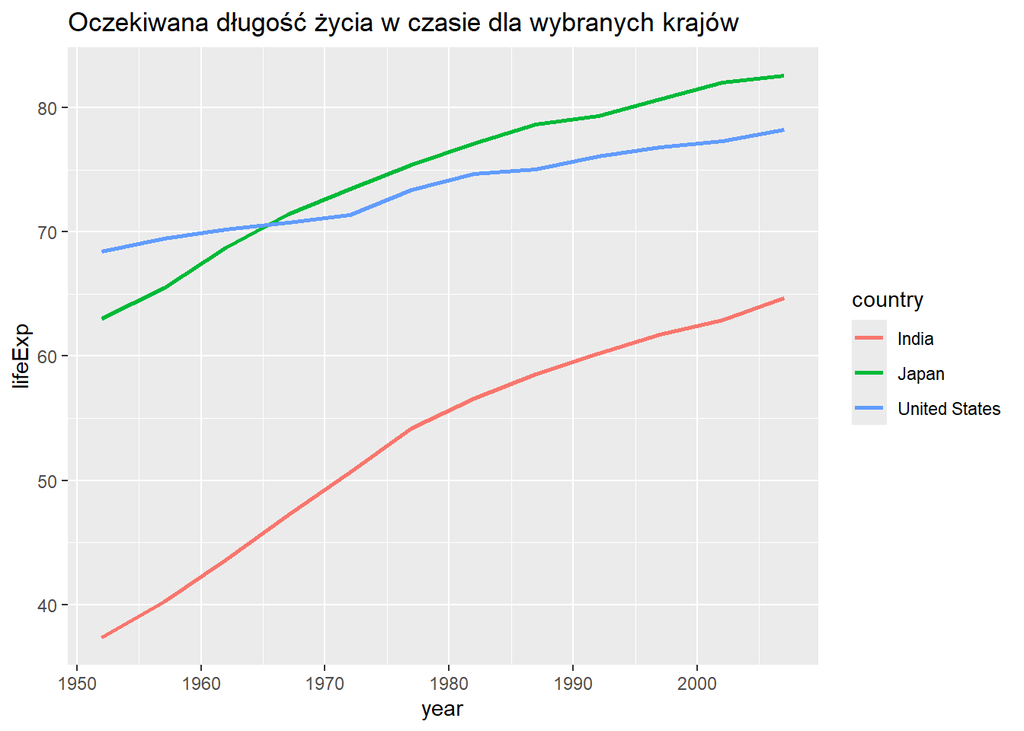

```r
gapminder %>% filter(country %in% c("Japan","United States","India")) %>%
ggplot(aes(x=year, y=lifeExp, color=country)) +
geom_line(size=1) +
labs(title="Oczekiwana długość życia w czasie dla wybranych krajów")
```

Najwyższe wartości osiągneła Japonia, natomiast Indie charakteryzowały się najniższą długością życia, choć również tam widoczny jest wyraźny trend wzrostowy.

# 2. Średnia PKB per capita według kontynentów

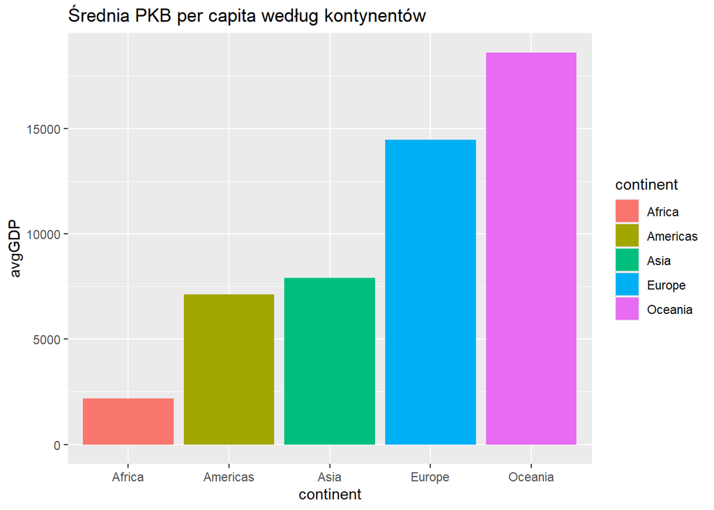

```r
gapminder %>% group_by(continent) %>% summarise(avgGDP = mean(gdpPercap)) %>%
ggplot(aes(x=continent, y=avgGDP, fill=continent)) +
geom_col() +
labs(title="Średnia PKB per capita według kontynentów")
```

Najwyższą średnią wartością PKB per capita charakteryzują się kraje Oceanii oraz Europy, natomiast najniższe wartości obserwowane są w Afryce. Wyniki te wskazują na znaczne różnice poziomu rozwoju gospodarczego pomiędzy kontynentami.

# 3. Zależność między PKB per capita a oczekiwaną długością życia

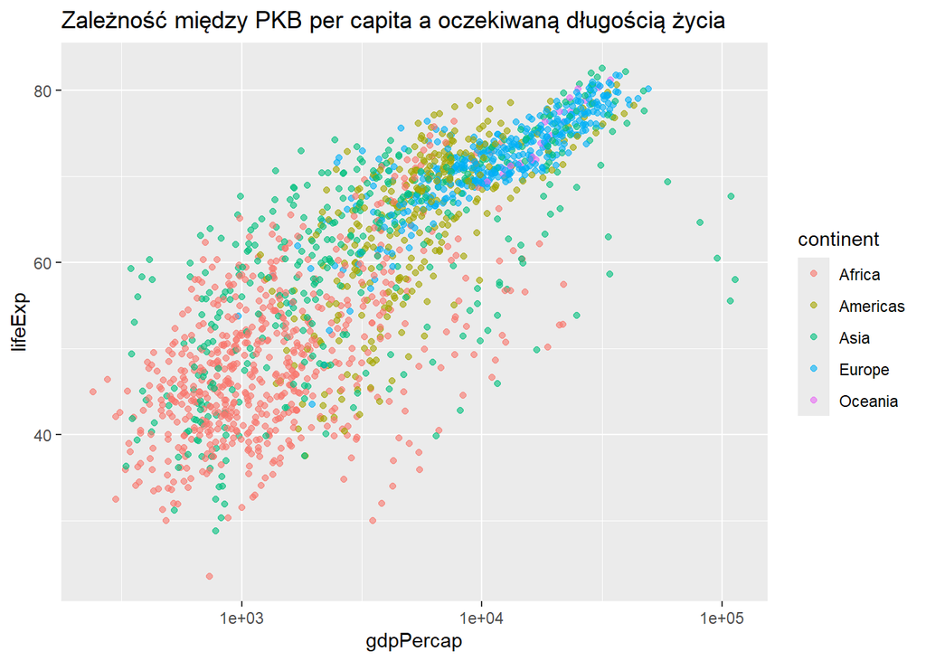

```r
ggplot(gapminder, aes(x=gdpPercap, y=lifeExp, color=continent)) +
geom_point(alpha=0.6) +
scale_x_log10() +
labs(title="Zależność między PKB per capita a oczekiwaną długością życia")
```

Widoczna jest dodatnia zależność między PKB per capita a oczekiwaną długością życia — kraje o wyższym poziomie PKB per capita cechują się dłuższą średnią długością życia mieszkańców, choć zależność ta nie jest idealnie liniowa.

# 4. Liczba ludności kontynentów w czasie

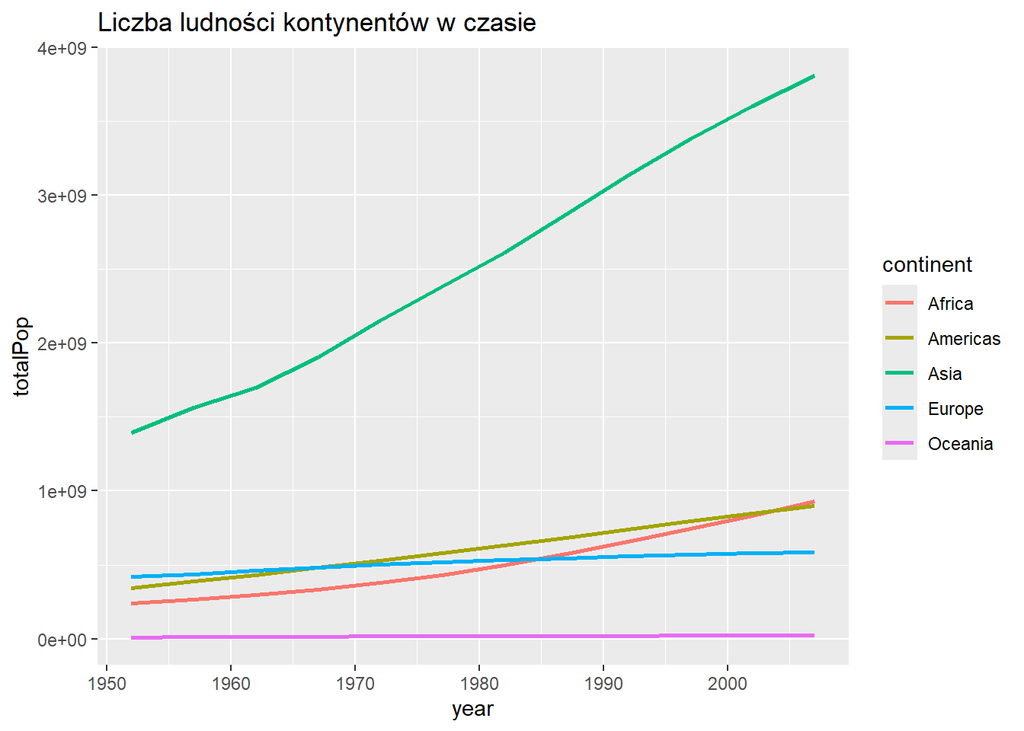

```r
gapminder %>% group_by(continent, year) %>% summarise(totalPop = sum(pop)) %>%
ggplot(aes(x=year, y=totalPop, color=continent)) +
geom_line(size=1) +
labs(title="Liczba ludności kontynentów w czasie")
```

Najszybszy wzrost populacji odnotowano w Azji i Afryce. Europa oraz Oceania wykazują znacznie wolniejsze tempo przyrostu ludności.

# 5. Kraje z najwyższym PKB per capita w 2007

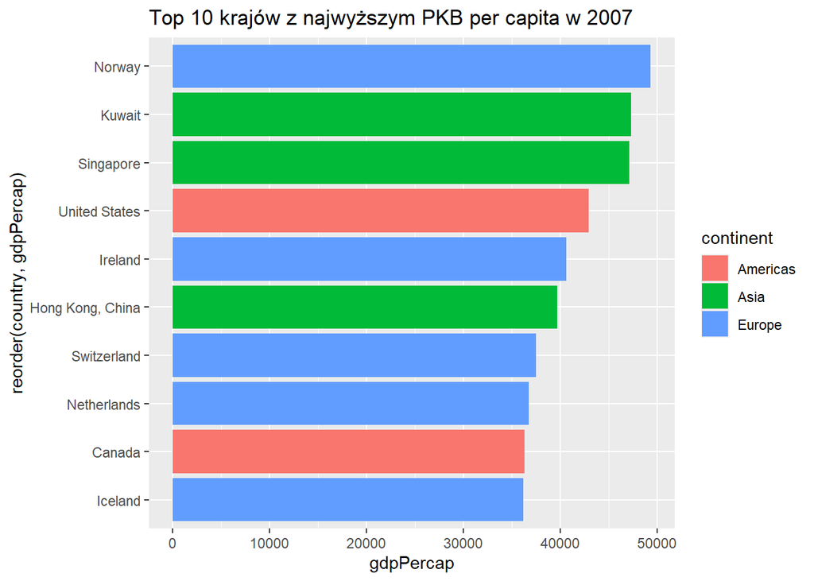

```r
gapminder %>% filter(year == 2007) %>% arrange(desc(gdpPercap)) %>% head(10) %>%
ggplot(aes(x=reorder(country, gdpPercap), y=gdpPercap, fill=continent)) +
geom_col() +
coord_flip() +
labs(title="Top 10 krajów z najwyższym PKB per capita w 2007")
```

# 6. Porównanie PKB per capita i oczekiwanej długości życia w 1952 i 2007

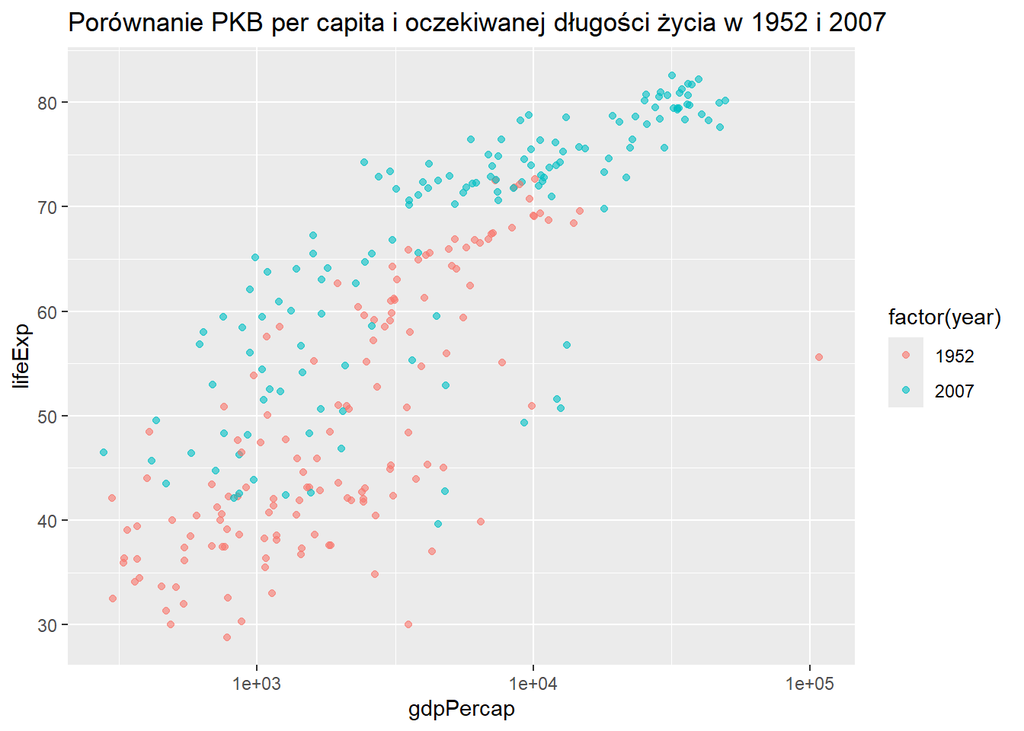

```r
gapminder %>% filter(year %in% c(1952,2007)) %>%
ggplot(aes(x=gdpPercap, y=lifeExp, color=factor(year))) +
geom_point(alpha=0.6) +
scale_x_log10() +
labs(title="Porównanie PKB per capita i oczekiwanej długości życia w 1952 i 2007")
```

W 2007 roku kraje charakteryzowały się zarówno wyższym PKB per capita, jak i dłuższą oczekiwaną długością życia w porównaniu do 1952 roku.

# 7. Kraje z największym wzrostem oczekiwanej długości życia

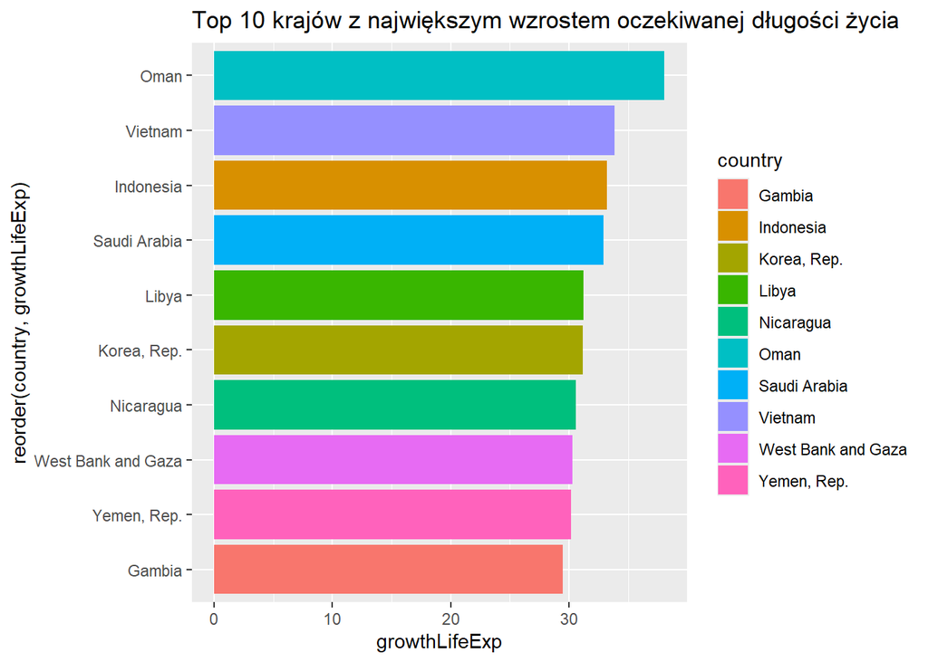

```r
gapminder %>%
group_by(country) %>%
summarise(growthLifeExp = lifeExp[year==2007] - lifeExp[year==1952]) %>%
arrange(desc(growthLifeExp)) %>%
head(10) %>%
ggplot(aes(x=reorder(country, growthLifeExp), y=growthLifeExp, fill=country)) +
geom_col() +
coord_flip() +
labs(title="Top 10 krajów z największym wzrostem oczekiwanej długości życia")
```